# Project proposal

## 3. Data analysis plan

In our categories that we are analyzing, we will be looking at how the percentages of students below, meeting, and exceeding expectations changes throughout a year. We will also look to see if there are correlations between the growth/decline of students in multiple categories. We plan to analyze the difference in trends between the Early Head Start Program and the Head Start Program. We plan on doing this by using histograms, bar plots, and faceting them to compare different sets of data.

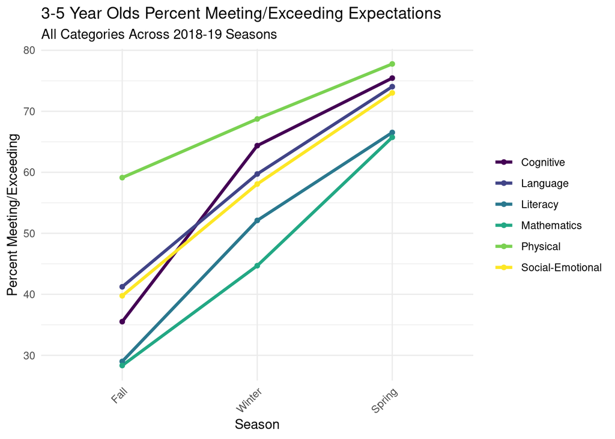

```r
HS_2018_19_data$season <- fct_relevel(HS_2018_19_data$season, "Fall", "Winter", "Spring")

ggplot(HS_2018_19_data, aes(x = season, y = percent_meeting_exceeding, group = category, color = category)) +
  stat_summary(fun = "mean", geom = "line", linewidth = 1.2) +  # Line for each category
  stat_summary(fun = "mean", geom = "point", linewidth = 3) +  # Points to highlight means
  labs(title = "3-5 Year Olds Percent Meeting/Exceeding Expectations",
       subtitle = "All Categories Across 2018-19 Seasons",
       x = "Season",
       y = "Percent Meeting/Exceeding") +
  scale_color_viridis_d() +
  theme_minimal() +
  theme(axis.text.x = element_text(angle = 45, hjust = 1),
        legend.title = element_blank())
```

```r
ggsave("season_trend_2018_19.jpeg", path = "../memo")
library(dplyr)
library(viridis)
```

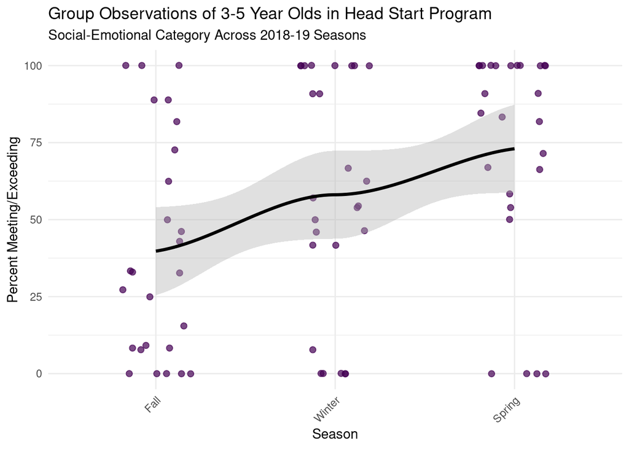

```r
# Filter for only the "Social-Emotional" category
social_emotional_data <- HS_2018_19_data %>%
  filter(category == "Social-Emotional")

# Relevel the season factor
social_emotional_data$season <- fct_relevel(social_emotional_data$season, "Fall", "Winter", "Spring")

# Use viridis color
point_color <- viridis(1, option = "D")  # Option "D" is the default and colorblind safe

# Plot
ggplot(social_emotional_data, aes(x = season, y = percent_meeting_exceeding)) +
  geom_jitter(width = 0.2, size = 2, alpha = 0.7, color = point_color) +
  geom_smooth(aes(group = 1), method = "loess", se = TRUE, color = "black", fill = "grey70", linewidth = 1.2) +
  labs(title = "Group Observations of 3-5 Year Olds in Head Start Program",
       subtitle = "Social-Emotional Category Across 2018-19 Seasons",
       x = "Season",
       y = "Percent Meeting/Exceeding") +
  theme_minimal() +
  theme(axis.text.x = element_text(angle = 45, hjust = 1))
```

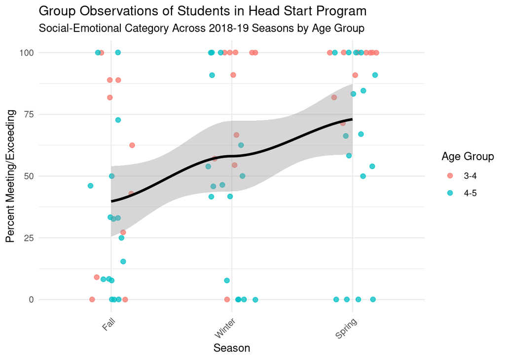

```r
# Filter for only the "Social-Emotional" category
social_emotional_data <- HS_2018_19_data %>%
  filter(category == "Social-Emotional")

# Relevel the season factor
social_emotional_data$season <- fct_relevel(social_emotional_data$season, "Fall", "Winter", "Spring")

# Plot with color by age group
ggplot(social_emotional_data, aes(x = season, y = percent_meeting_exceeding)) +
  geom_jitter(aes(color = age_group), width = 0.2, size = 2, alpha = 0.75) +
  geom_smooth(aes(group = 1), method = "loess", se = TRUE, color = "black", linewidth = 1.2) +
  labs(title = "Group Observations of Students in Head Start Program",
       subtitle = "Social-Emotional Category Across 2018-19 Seasons by Age Group",
       x = "Season",
       y = "Percent Meeting/Exceeding",
       color = "Age Group") +
  theme_minimal() +
  theme(axis.text.x = element_text(angle = 45, hjust = 1))
```

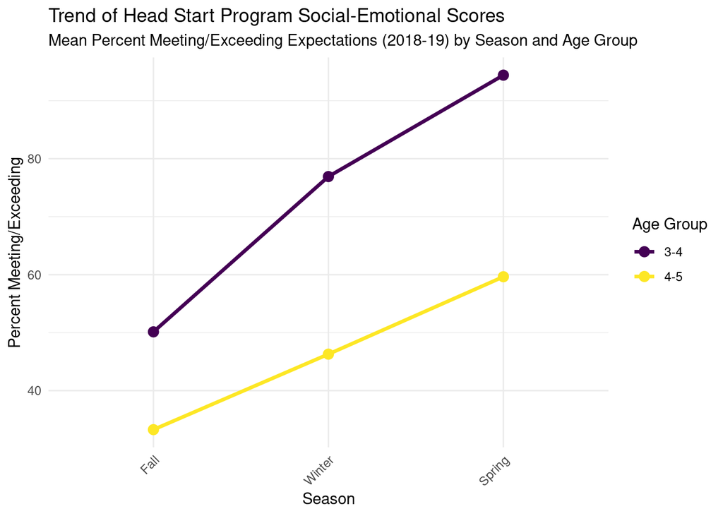

```r
# Filter for only the "Social-Emotional" category
social_emotional_data <- HS_2018_19_data %>%
  filter(category == "Social-Emotional")

# Relevel season factor
social_emotional_data$season <- fct_relevel(social_emotional_data$season, "Fall", "Winter", "Spring")

# --- Plot 1: Grouped Line Plot for Mean Trends ---
ggplot(social_emotional_data, aes(x = season, y = percent_meeting_exceeding,
                                               group = age_group, color = age_group)) +
  stat_summary(fun = mean, geom = "line", linewidth = 1.2) +
  stat_summary(fun = mean, geom = "point", size = 3) +
  scale_color_viridis_d(option = "D") +
  labs(title = "Trend of Head Start Program Social-Emotional Scores",
       subtitle = "Mean Percent Meeting/Exceeding Expectations (2018-19) by Season and Age Group",
       x = "Season", y = "Percent Meeting/Exceeding",
       color = "Age Group") +
  theme_minimal() +
  theme(axis.text.x = element_text(angle = 45, hjust = 1))
```

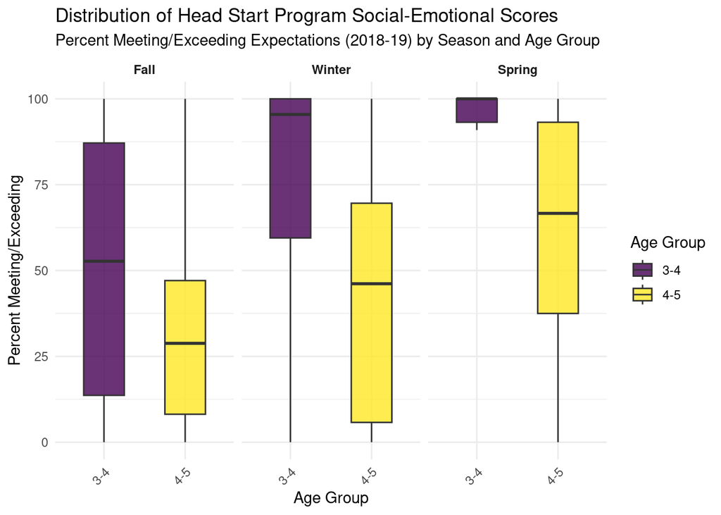

```r
ggsave("2018_19_3_4_vs_4_5_line_plot.jpeg", path = "../memo")
# Filter for only the "Social-Emotional" category
social_emotional_data <- HS_2018_19_data %>%
  filter(category == "Social-Emotional")

# Relevel season factor
social_emotional_data$season <- fct_relevel(social_emotional_data$season, "Fall", "Winter", "Spring")

# --- Plot 2: Faceted Boxplot with Jittered Points ---
ggplot(social_emotional_data, aes(x = age_group, y = percent_meeting_exceeding, fill = age_group)) +
  geom_boxplot(width = 0.5, outlier.shape = NA, alpha = 0.8) +
  facet_wrap(~ season) +
  scale_fill_viridis_d(option = "D") +
  labs(title = "Distribution of Head Start Program Social-Emotional Scores",
       subtitle = "Percent Meeting/Exceeding Expectations (2018-19) by Season and Age Group",
       x = "Age Group", y = "Percent Meeting/Exceeding",
       fill = "Age Group") +
  theme_minimal() +
  theme(strip.text = element_text(face = "bold"),
        axis.text.x = element_text(angle = 45, hjust = 1))
```

```r
ggsave("2018_19_boxplot_seasons.jpeg", path = "../memo")
```

## 4. Data Ethics Review

The data ethics review section will be introduced in a separate class and is not part of the original proposal deadline.